# Plants Nutrient Uptake and the Soil Community

## Overview of Plant Nutrient Uptake

- **Review: Plants require many mineral nutrients for growth, development, and metabolism**
  - nutrients are absorbed primarily through roots from the soil solution
- **Two main pathways for uptake:**
  - passive transport (diffusion, facilitated diffusion)
  - active transport (requires energy to move ions against gradient)
- **Most nutrients enter roots as ions dissolved in water (e.g., NO₃⁻, K⁺)**
  - plants can’t absorb solid particles directly
  - charged ions require transport proteins (in cells)

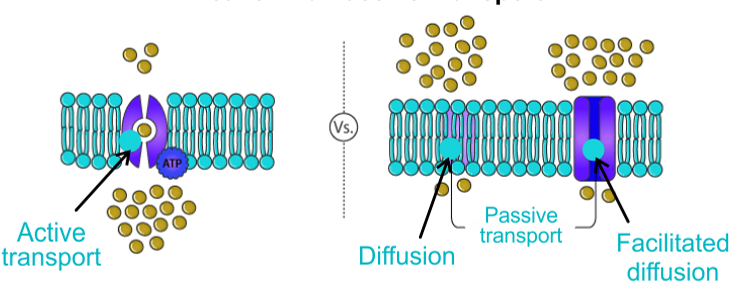

## Root Hair Cells: Structure and Function

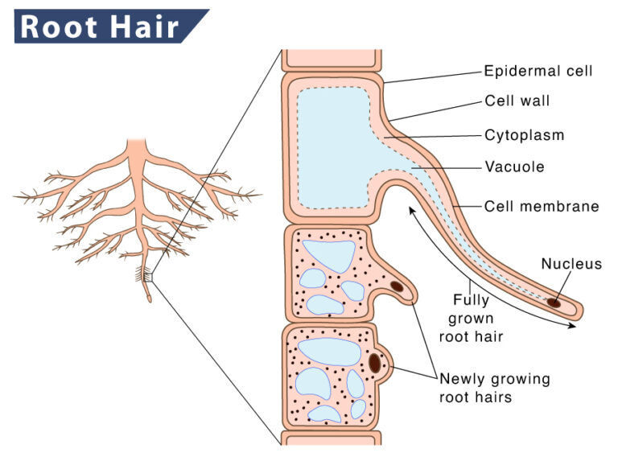

- **Root hair cells are extensions of epidermal cells in the root**
  - Increase surface area dramatically
  - No waxy cuticle, so water enters freely
  - High density of membrane transport proteins for selective nutrient uptake
- **Thin cell walls and large central vacuole aid in rapid uptake of ions and water**
  - lots of mitochondria (?)
- **Short-lived but continuously regenerated as roots grow through new soil zones**

## Active Uptake of Nutrients via Roots

- **Roots absorb scarce nutrients even when concentrations are higher inside the cell than in the soil**
  - passive diffusion would not work
  - ATP needed to transport across gradient
- **Root cells use energy to pump out hydrogen ions (H⁺) into the soil**
  - creates a gradient that helps pull *anions* (negatively charged) like nitrate and phosphate into roots
- **Soil particles are negatively charged, holding cations (i.e. Ca<sup>2+</sup>)**
  - hydrogen ions also cause cations to be swapped out into soil water

## Active Uptake of Nutrients via Roots

[figure not shown]

## Root Structure & Nutrient Entry

**Dissolved nutrients move between cells and through cell walls to reach xylem**

**Apoplastic pathway: movement through cell walls and intercellular spaces**

**Symplastic pathway: movement from cell to cell through plasmodesmata (tiny bridges between cells)**

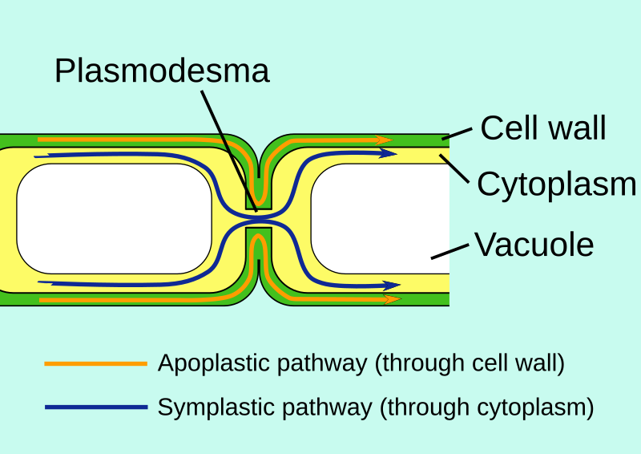

## Root Structure & Nutrient Entry

**Casparian strips are located in the cell walls of the layer of cells that surround the vascular cylinder in plant roots (xylem + phloem)**

**Forces selective uptake into symplast before xylem**

**Symplast pathways uses plasmodesmata - small channels that are lined with plasma membrane (selectively permeable!)**

**Allows regulation of molecule movement, prevents back flow, and prevents entry of pathogens into vascular system**

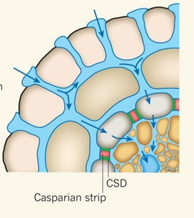

## Plants and Fungi

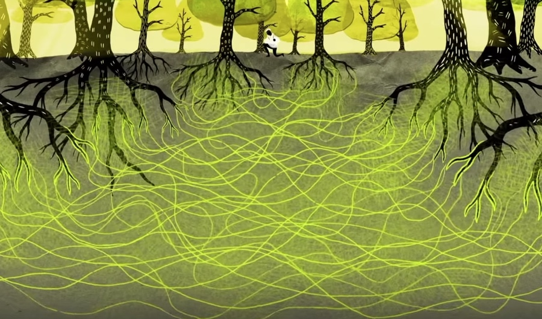

## Mycorrhizal fungi: sharing with plants

- **~80-90% of plants have association with fungus**
  - fungi grow in/around plant roots
  - share resources
  - one of the most widespread mutualisms
- **2 main types:**
  - Ecto- and Endo- mycorrhizae
  - diverse array of species for each
- **Association now key for plants to thrive**
  - fungi more efficient @ nutrient uptake

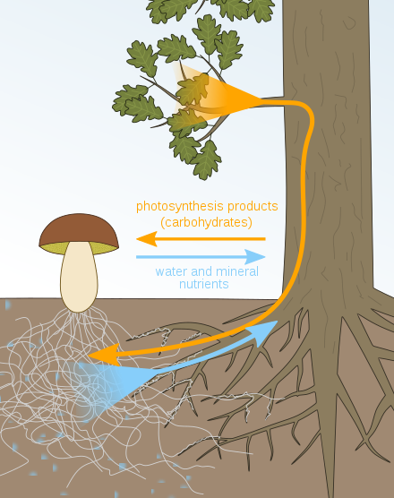

## All Fungi share traits related to nutrition

- **Use enzymes to break down compounds**
  - diverse enzymes for diverse food sources
- **Heterotrophs: absorb nutrients from environment**
  - decomposers: break down dead things
  - parasites: absorb from host
  - mutualist: absorb/share with host

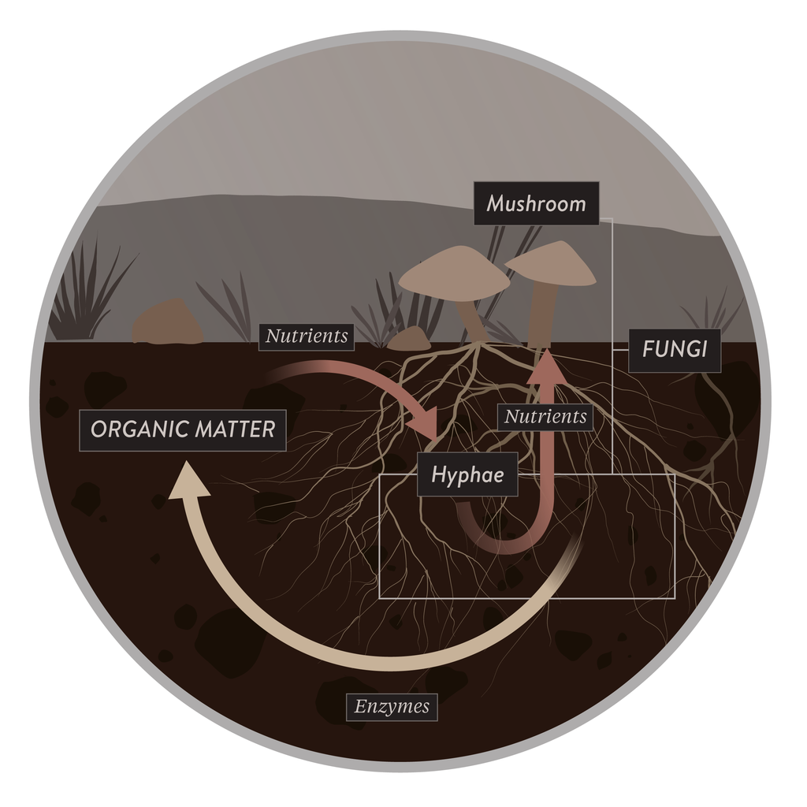

## Fungal body plan: Not-motile

[figure not shown]

## Most *hyphae* divided into cells by *septa*

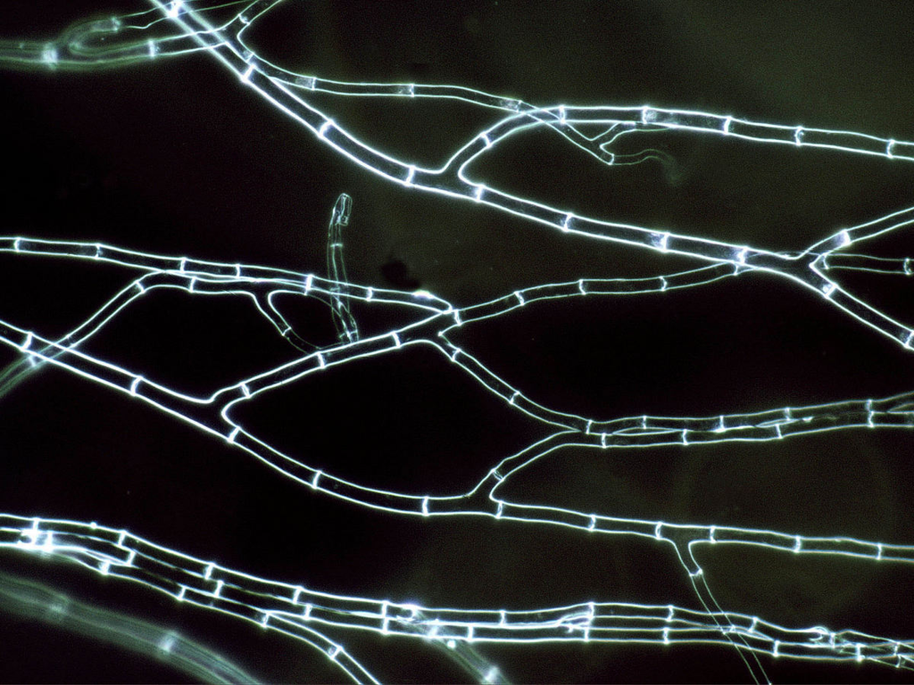

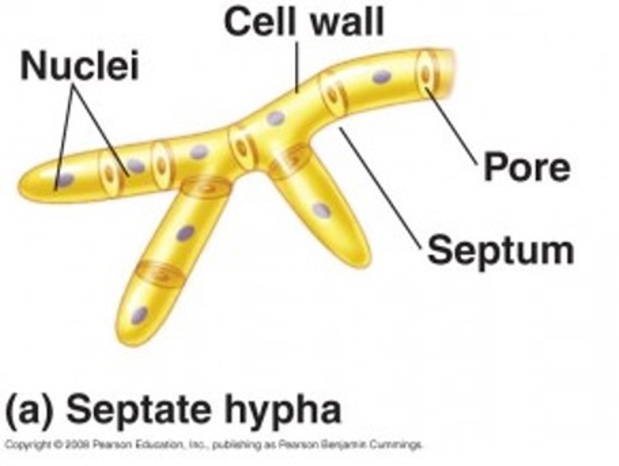

## Mycelium: huge surface and volume for absorption

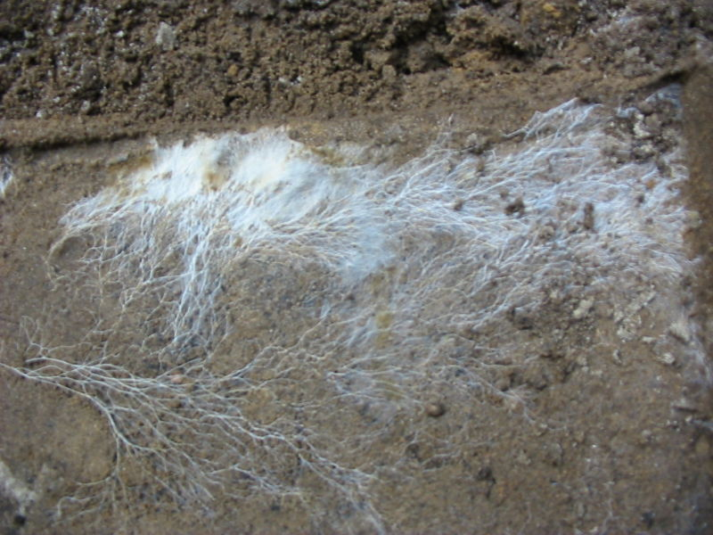

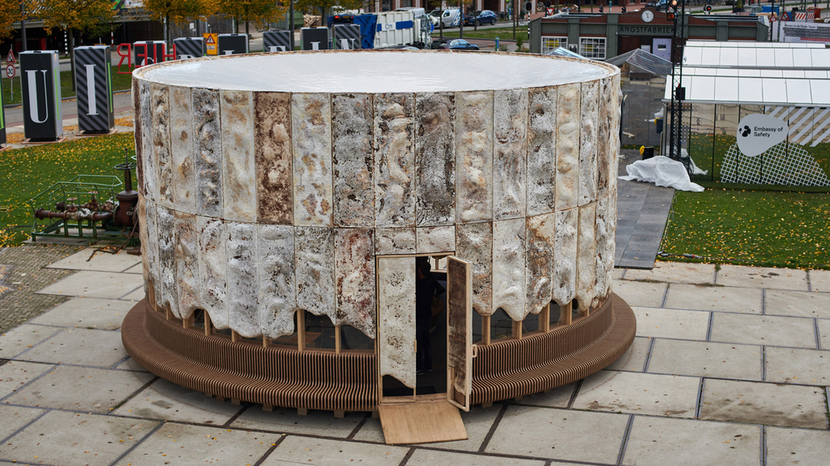

## Specialized hypae in many types of fungi

- **Specialized hyphae for feeding on live animals**
  - hoops
- **Specialized hyphae that allow them to extract nutrients from plants**

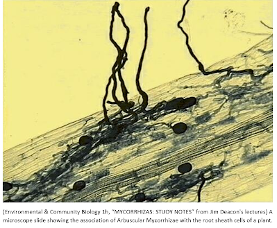

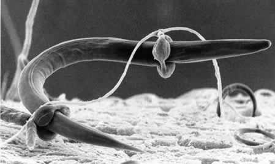

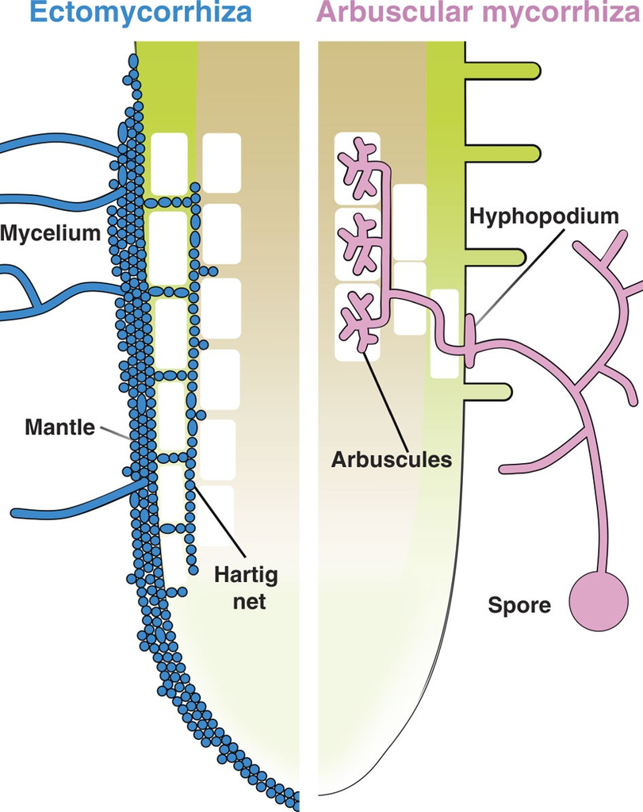

- **Branching hyphae used to exchange nutrients with plant hosts**
- **Ectomycorrhizal fungi form ‘sheath’ around cell walls**
  - *Hartig net* surrounds epidermal cells
- **Endomycorrhizal fungi penetrate cell walls**
  - *Arbuscules*: highly branched hyphae inside cells
  - often called ‘arbuscular’ mycorrhizae

[figure not shown]

## Nutrient Exchange: Sharing benefits both species

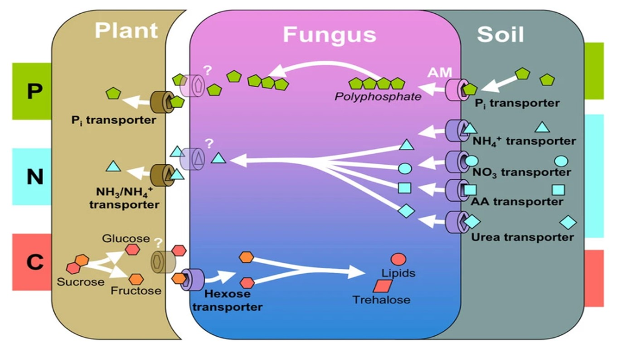

## Soil Life: Plant Roots, Fungi & *Microbes*

- **Free-living microbial communities in soils breakdown organic matter**
  - plants cannot uptake organic compounds
  - fungi lost some breakdown enzymes via evolution
- **Microbial communities are carbon limited**
  - plants exude carbon (simple sugars) from root tips
  - exudates increases microbial activity
- **Fungi are great at uptake and transport**
  - decomposers of *some* things
  - also carbon limited

[figure not shown]

## Timing matters: Land plant evolution & fungi

- **Fungal phyla associated with mycorrhizae diverged prior to the divergence of land plants**
  - Oldest fungal fossils appear ~900 mya
  - First terrestrial fungus ~ 460 mya
- **Early plant groups (bryophytes) do not have roots and maintain limited/no association with fungi**
- **Vascular plant land colonization likely facilitated by interactions with symbiotic fungi**
  - fossil evidence shows similarity in timing
  - needs of both groups still relevant

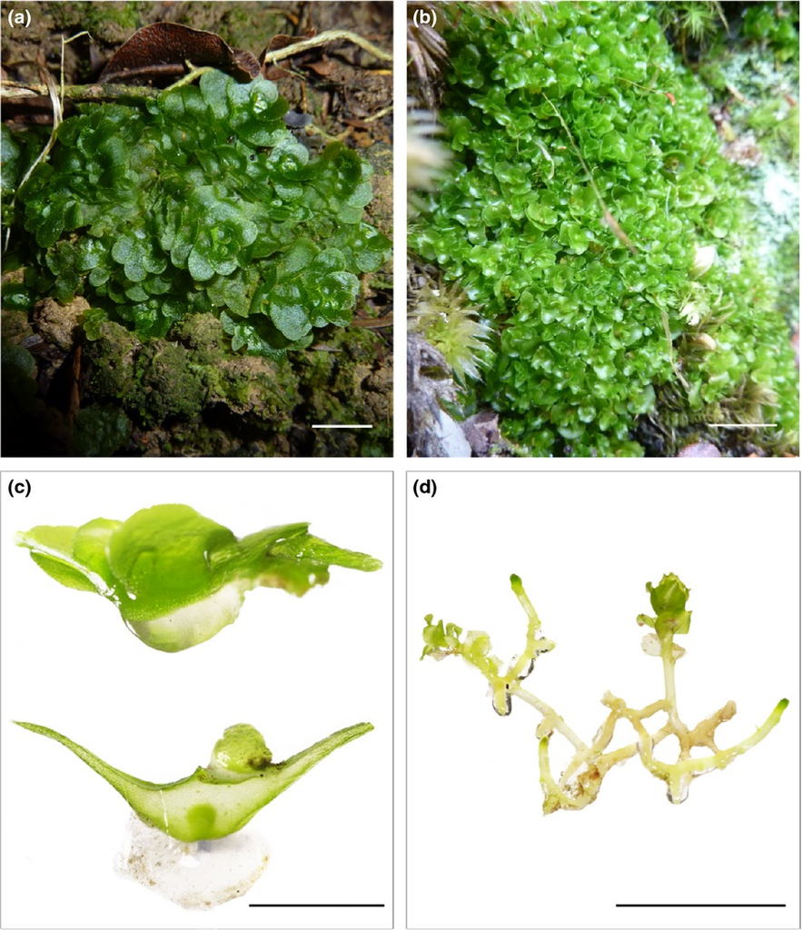

## Role of mycorrhizae in agrosystems: Nutrients

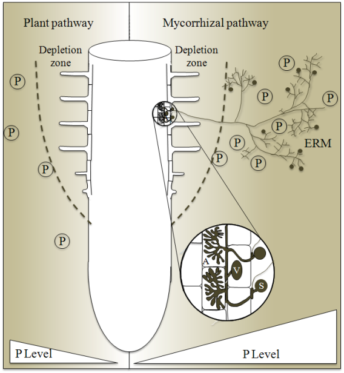

## Sustainable agriculure with mycorrhizae

[figure not shown]

- **Plant herbivory signals through fungal network between plants**
  - neighbors can turn on chemical defenses
  - fungi help induce these chemical defenses (VOC’s)
- **Nutrients benefits of symbiosis mean more flowers & nectar**
  - increases pollination
- **Fungal hypae release polysaccrides that bind soil particles**
  - holds more water
  - stores more carbon
  - reduces erosion & leaching
  - improves microbial biodiversity

## The current state of agriculture: Role of fungi

- **Dramatic ↑ in crop productivity last century**
  - development of pesticides, fertilizers
  - plant breeding and genetic technologies
- **Now, crop yields have plateaued & fertilizer production unsustainable**
  - climate change
  - over population
  - nutrient depletion
  - energy prices
- **High levels of fertilizer reduces fungal-root associations**
- **Big challenges to global food security**

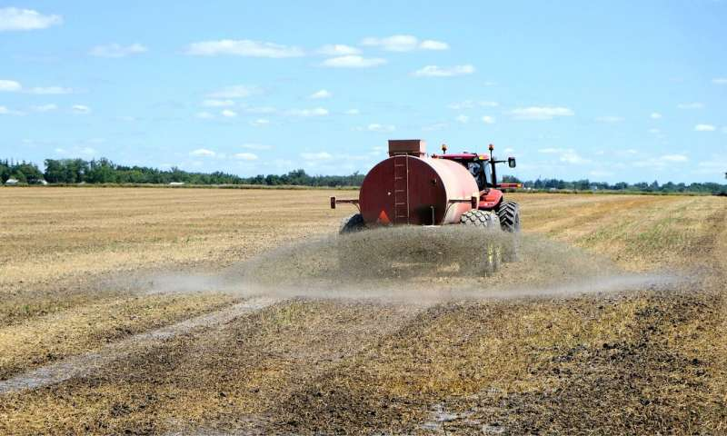

## Are fungi always a good thing?

- **Fungal pathogens exist (non-mycorrhizal)**
- **Not all crops have fungal symbioses**
  - broccoli, mustard, spinach, beets
  - does this create competition?
- **Dependency on mycorrhizae varies greatly**
  - wheat vs corn
- **How far does ‘sharing is caring’ go?**
  - can the relationship become parasitic?

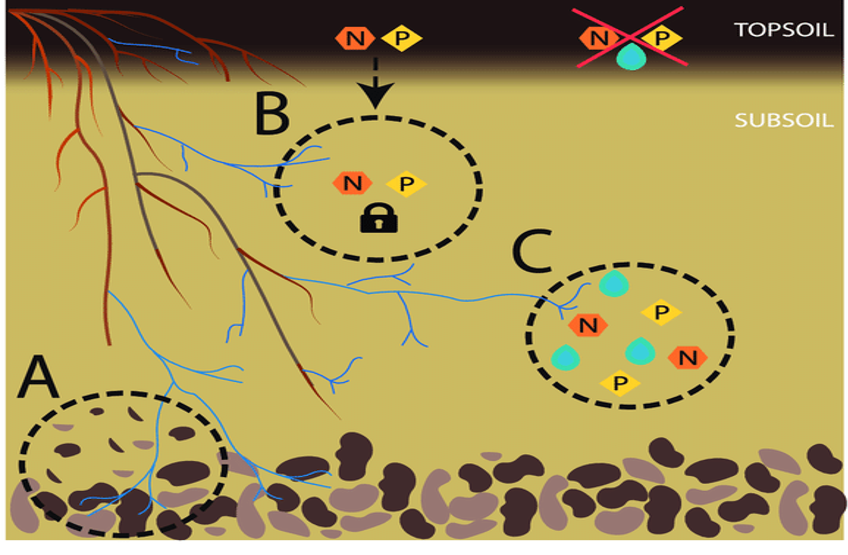